# Ecology 8540 Computational Workshops

May 23, 2021  
Materials at https://github.com/CEIDatUGA/ECOL8540-datavis

## Graphic Perception

**Physics** = the study of physical phenomena

**Psychophysics** = the study of the *perception* of physical phenomena

Psychophysics studies the relationship between a physical stimulus and our perceptual system’s response.

**Graphical Perception** = the ability of viewers to interpret visual (graphical) encodings of information and thereby decode information in graphs.

### Graphical Perception

Signal Detection  
Magnitude Estimation  
Pre-Attentive Processing  
Multiple Visual Encodings  
Gestalt  
Change Blindness

### Graphical Perception

Signal Detection  
Magnitude Estimation  
Pre-Attentive Processing  
Multiple Visual Encodings  
Gestalt  
Change Blindness

**Signal** = information

**Noise** = everything else

**Threshold** = minimum detectable stimulus (or maximum tolerable stimulus)

**Just-Noticeable Difference (JND)** = smallest perceivable *change* in stimulus

### Graphical Perception

Signal Detection  
Magnitude Estimation  
Pre-Attentive Processing  
Multiple Visual Encodings  
Gestalt  
Change Blindness

### JND for Brightness

### Graphical Perception

Signal Detection  
Magnitude Estimation  
Pre-Attentive Processing  
Multiple Visual Encodings  
Gestalt  
Change Blindness

### JND for Brightness

[figure not shown]

### Graphical Perception

Signal Detection  
Magnitude Estimation  
Pre-Attentive Processing  
Multiple Visual Encodings  
Gestalt  
Change Blindness

### JND for Brightness

### Graphical Perception

Signal Detection  
Magnitude Estimation  
Pre-Attentive Processing  
Multiple Visual Encodings  
Gestalt  
Change Blindness

### JND for Brightness

### Graphical Perception

Signal Detection  
Magnitude Estimation  
Pre-Attentive Processing  
Multiple Visual Encodings  
Gestalt  
Change Blindness

### JND for Brightness

[figure not shown]

### Graphical Perception

Signal Detection  
Magnitude Estimation  
Pre-Attentive Processing  
Multiple Visual Encodings  
Gestalt  
Change Blindness

### JND for Brightness

**Weber’s Law:**

\[ JND = \Delta I = Change\;in\;Intensity \]

\[ k = \frac{\Delta I}{I} = \frac{JND\;(Change\;in\;Intensity)}{Original\; Intensity} \]

k is some constant. This means that the bigger the original intensity, the bigger the increase needs to be to detect a change.

In other words, it’s the *ratio* of intensities that matters.

Weber’s Law holds for most perceptual phenomena, including visual, aural, tactile, etc., **but each has it’s own value k.** Perception in general is *logarithmic* (depends on ratios).

For Brightness (Intensity of Light), k = 0.08

For Loudenss (Intensity of Sound), k = 0.05

### Graphical Perception

Signal Detection  
Magnitude Estimation  
Pre-Attentive Processing  
Multiple Visual Encodings  
Gestalt  
Change Blindness

### JND for Brightness

**Weber’s Law:**

So,

\[ 0.08 = \frac{\Delta I}{I} = \frac{JND\;(Change\;in\;Brightness)}{Original\; Brightness} \]

So, to find the smallest perceivable difference in brightness, you can multiply the original by 0.08 (if you have a light meter).

**PROBLEM:** You can’t do that with normal RGB, CMYK or Hex color values! Those color spaces are lonlinear, and so is our perception, but in different ways. So you can’t just multiply. You can only multiply light intensity values measured with a light meter!

**SOLUTION:** Use a “perceptually uniform” colorspace (like CIE-LAB), which has been designed based on empirical study of human perception.

Tools exist to automatically generate perceptually uniform color and brightness scales, and color pallets. The best visualization software has these scales or tools built in.

### Graphical Perception

Signal Detection  
Magnitude Estimation  
Pre-Attentive Processing  
Multiple Visual Encodings  
Gestalt  
Change Blindness

### Graphical Perception

Signal Detection  
Magnitude Estimation  
Pre-Attentive Processing  
Multiple Visual Encodings  
Gestalt  
Change Blindness

## Stevens’ Power Law

Psychophysics is the quantitative description of the relationship between physical stimuli and perception (response).

\(\psi(I) = kI^\alpha\)

Stevens’ Power Law describes the subjective response \(\psi\) to the magnitude of physical stimulus \(I\).

Stevens fit power laws as a first approximation to experimental data.

Data were collected by asking subjects to provide subjective ratios in response to pairs of stimuli.  
Subsequent researchers come up with different values of \(\alpha\).  
Responses are highly subjective for some stimuli.  
Wilkinson has a good discussion in Grammar of Graphics.

Stevens, S. S. (1957). On the psychophysical law. Psychological Review, 64(3), 153-181: http://dx.doi.org/10.1037/h0046162

## Stevens’ Power Law

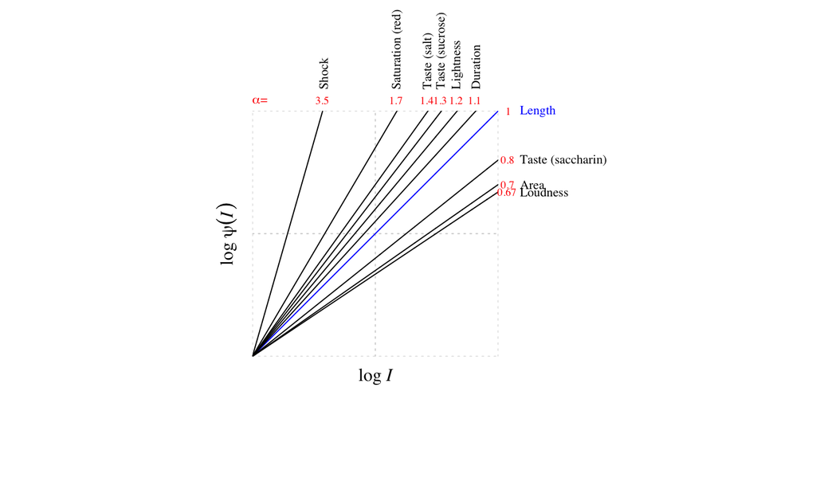

| continuum | exponent | condition |
| --- | --- | --- |
| Loudness | 0.67 | Sound pressure of 3000 Hz tone |
| Vibration | 0.95 | Amplitude of 60 Hz on finger |
| Vibration | 0.60 | Amplitude of 250 Hz on finger |
| Brightness | 0.33 | 5 deg target in dark |
| Brightness | 0.50 | Point source |
| Brightness | 0.50 | Brief flash |
| Brightness | 1.00 | Point source briefly flashed |
| Lightness | 1.20 | Reflectance of gray papers |
| Length | 1.00 | Projected line |
| Area | 0.70 | Projected square |
| Saturation | 1.70 | Red–gray mixture |
| Taste | 1.30 | Sucrose |
| Taste | 1.40 | Salt |
| Taste | 0.80 | Saccharin |
| Smell | 0.60 | Heptane |
| Cold | 1.00 | Metal contact on arm |
| Warmth | 1.60 | Metal contact on arm |
| Warmth | 1.30 | Irradiation of skin, small area |
| Warmth | 0.70 | Irradiation of skin, large area |
| Discomfort, cold | 1.70 | Whole-body irradiation |
| Discomfort, warm | 0.70 | Whole-body irradiation |
| Thermal pain | 1.00 | Radiant heat on skin |
| Tactual roughness | 1.50 | Rubbing emery cloths |
| Tactual hardness | 0.80 | Squeezing rubber |
| Finger span | 1.30 | Thickness of blocks |
| Pressure on palm | 1.10 | Static force on skin |
| Muscle force | 1.70 | Static contractions |
| Heaviness | 1.45 | Lifted weights |
| Viscosity | 0.42 | Stirring silicone fluids |
| Shock | 3.50 | Current through fingers |
| Vocal effort | 1.10 | Vocal sound pressure |
| Angular acceleration | 1.40 | 5 s rotation |
| Duration | 1.10 | White-noise stimuli |

## Take-away:

“Length” is the only visual parameter with 1:1 linear perceptual response curve, so…

1. **plot your most important variables using length** (or x y position) in 2D  
   (line charts, bar charts, scatterplots, etc.)
2. Reserve other visual parameters (color, area, etc.) for **less important variables**
3. When not using length, use **perceptually uniform scales** (mostly applies to color)
4. Best mappings depend on the nature of the data (Quantitative, Ordinal, Nominal)

## Mackinlay’s effectiveness rankings (simplified) :

Mackinlay, Jock. *[Automating the Design of Graphical Presentations of Relational Information.](https://research.tableau.com/sites/default/files/p110-mackinlay.pdf).* ACM Transactions on Graphics, Vol. 5, No. 2, April 1986.

**Quantitative**

Position  
Length  
Angle  
Slope  
Area  
Volume  
Value (color)  
Saturation (color)  
Hue (color)  
Shape

**Ordinal**

Position  
Value (color)  
Saturation (color)  
Hue (color)  
Length  
Angle  
Slope  
Area  
Volume  
Shape

**Nominal**

Position  
Hue (color)  
Value (color)  
Saturation (color)  
Shape  
Length  
Angle  
Slope  
Volume

## Perceptually uniform pitch-loudness scale

[interactive chart not shown]

*31.5 Hz to 12,500 Hz, **equal SPL** (horizontal line on left plot):*

[interactive chart not shown]

*31.5 Hz to 12,500 Hz at **equal loudness** (80 phon equal loudness contour):*

[interactive chart not shown]

### Graphical Perception

Signal Detection  
Magnitude Estimation  
Pre-Attentive Processing  
Multiple Visual Encodings  
Gestalt  
Change Blindness

[figure not shown]

### Graphical Perception

Signal Detection  
Magnitude Estimation  
Pre-Attentive Processing  
Multiple Visual Encodings  
Gestalt  
Change Blindness

**Pre-attentive processing** = unconscious imformation processing

- The brain first pre-processes all the information in a scene unconsciously.
- The most salient information is passed on for conscious (attentive) processing.

**Salient Information** is information that:

- stands out the most (“pops”), or
- is relevant to what a person is thinking about

https://en.wikipedia.org/wiki/Pre-attentive_processing

https://en.wikipedia.org/wiki/Feature_integration_theory

### Graphical Perception

Signal Detection  
Magnitude Estimation  
Pre-Attentive Processing  
Multiple Visual Encodings  
Gestalt  
Change Blindness

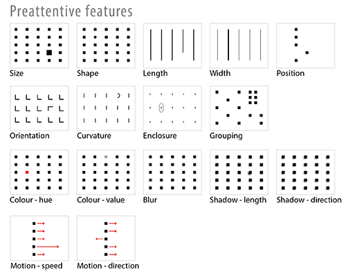

image credit: Anne Stevens. http://stevensanne.com/data-viz-in-6-weeks-wk-3-perception-cognition/

### Graphical Perception

Signal Detection  
Magnitude Estimation  
Pre-Attentive Processing  
Multiple Visual Encodings  
Gestalt  
Change Blindness

**Unique single features** are detected preattentively more easily than combinations of features.

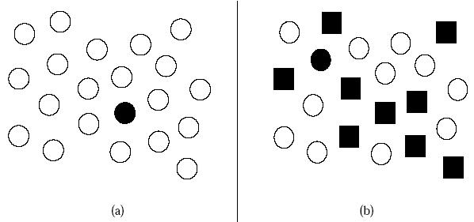

### Graphical Perception

**Single dimension encodings**

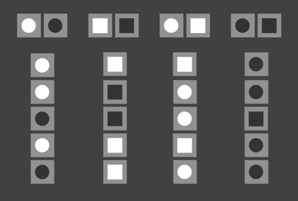

based on slide by Jeff Heer

### Graphical Perception

Signal Detection  
Magnitude Estimation  
Pre-Attentive Processing  
Multiple Visual Encodings  
Gestalt  
Change Blindness

**Redundant encodings** can help pre-attentive processing.

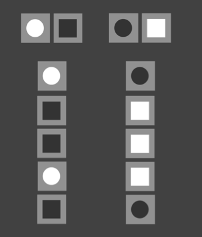

based on slide by Jeff Heer

### Graphical Perception

Signal Detection  
Magnitude Estimation  
Pre-Attentive Processing  
Multiple Visual Encodings  
Gestalt  
Change Blindness

**“Orthagonal” encodings** can interfere with pre-attentive processing.

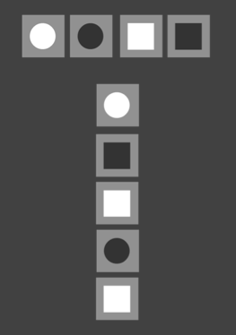

based on slide by Jeff Heer

### Graphical Perception

Signal Detection  
Magnitude Estimation  
Pre-Attentive Processing  
Multiple Visual Encodings  
Gestalt  
Change Blindness

**Gestalt:** “shape or form” (German)

**Gestalt Theory** tries to explain how our brain generates mental perceptions of whole forms out of incomplete or chaotic stimulus.

[figure not shown]

https://en.wikipedia.org/wiki/Gestalt_psychology

### Graphical Perception

Signal Detection  
Magnitude Estimation  
Pre-Attentive Processing  
Multiple Visual Encodings  
Gestalt  
Change Blindness

### Principles

**Emergence:** Recognition occurs all at once, holistically. (We don’t build up a percept or mental image of an object consciously.)  
**Reification:** The percept (mental image) can contains more information than the stimuli on which it is based. (We fill in missing pieces of a whole.)  
**Multistability:** Ambiguous perceptual experiences pop back and forth between interpretations. (We don’t know why.)  
**Invariance:** Simple geometrical objects are recognized independent of rotation, translation, scale and several other variations.

**Emergence:** Recognition occurs all at once, holistically. (We don’t build up a percept or mental image of an object consciously.)

[figure not shown]

**Reification:** The percept (mental image) can contains more information than the stimuli on which it is based. (We fill in missing pieces of a whole.)

[figure not shown]

**Multistability:** Ambiguous perceptual experiences pop back and forth between interpretations. (We don’t know why.)

[figure not shown]

**Invariance:** Simple geometrical objects are recognized independent of rotation, translation, scale and several other variations.

[figure not shown]

### Graphical Perception

Signal Detection  
Magnitude Estimation  
Pre-Attentive Processing  
Multiple Visual Encodings  
Gestalt  
Change Blindness

### Grouping

- Proximity
- Similarity
- Closure
- Symmetry
- Common Fate
- Continuity
- “Good Gestalt” / Prägnaz (“pithiness”)
  - Simplest forms, rhythm, pattern, etc. leads to grouping
- Past Experience
  - a z b c y x

**Proximity**

[figure not shown]

**Similarity**

[figure not shown]

**Closure**

[figure not shown]

**Symmetry**

[figure not shown]

**Continuity**

[figure not shown]

**Pragnanz**

[figure not shown]

### Graphical Perception

Signal Detection  
Magnitude Estimation  
Pre-Attentive Processing  
Multiple Visual Encodings  
Gestalt  
Change Blindness

## INSTRUCTIONS:

### In the following video, count how many passes the players in white make.

[video not shown]

## Workflows

## Education & Public Outreach (print)

Reproducibility is secondary, but you should still preserve a record of steps.

EPO materials should still be data-accurate.

- make basic data plots in R
- save as or export as PDF
- open PDF’s in a drawing program (Inkscape or Adobe Illustrator)
- release clipping masks, ungroup, etc.
- all plot elements are “vector art” and can be scaled up without loss (may be burried)

## Interactivity

Interactive plots and dashboards can be made in R using `shiny` (with a considerable learning curve). A simple and powerful way to generate interactive plots is with Plotly, using the `rplotly` package.

An example R script that generates an interactive dashbaord is provided in `R/interactive_example.R`

Plots made with ggplot can easily be made interactive by passing them to plotly’s `ggplotly` function.

## Reproducible Figures for Pubication (print)

Many journals will accept PDF files for figures. PDF gives you the maximum control over the details of your plot (relative sizes, fonts, etc.), and will always print with no loss of resolution. If the journal requires a TIFF, the PDF can be converted to a high resolution TIFF.

Encode all the journal figure requirements (fonts, font sizes, figure widths, etc.) as variables outside of your plot.

Use the PDF graphics device `pdf()` to capture your plot.

Pass graphic variables to the PDF graphics device `pdf()` and to the plot.

Full workflow in `exercises/5_publication_workflow.Rmd`